# Optimal_port2

Panther

February 19, 2018

## Load Data

```r
library(quanteda); library(tidyverse); library(TTR);library(ggplot2);library(scales); library(fOptions); library(pastecs); library(psych);library(crayon);library(PerformanceAnalytics);library(stats);library(RQuantLib);

# here data read is being processed
setwd("F:/Dropbox/[IAQF_Max]/R")

#t <- read_csv("../data/data_div.csv")
#t <- read_csv("../Data/data.csv")
#t <- read_csv("F:/Dropbox/[IAQF]/Data/data.csv")
# t$Date <- strptime(as.character(t$Date), "%m/%d/%Y")
# format(t$Date, "%Y-%m-%d")
# t$Date <- as.Date(t$Date)
```

# Process Data

```r
GSPC <- read_csv("../data/^GSPC.csv")
Treasury <- read_csv("../data/DTB3.csv")
VIX <- read_csv("../data/^VIX.csv")
DIV <- read_csv("../data/Dividends.csv")
DIV_M <- read_csv("../data/SP500_DIV_YIELD_MONTH.csv")
# DIV$`SPX Index` <- strptime(as.character(DIV$`SPX Index`), "%m/%d/%Y")
# format(DIV$`SPX Index`, "%Y-%m-%d")
# DIV$`SPX Index` <- as.Date(DIV$`SPX Index`)
# t <- t[-10]

t<-cbind(GSPC,Treasury$DTB3[match(GSPC$Date,Treasury$DATE)])
t<-cbind(t,VIX$Close[match(t$Date,VIX$Date)])
t<-cbind(t,DIV$X2[match(t$Date,DIV$`SPX Index`)])

t<-t[,c(1,5,8,9,10)]
t<- t[-1:(-10054+250),]  # extra 120 for training signal, will remove later
colnames(t)[3] <- "Free_rate"
colnames(t)[4] <- "VIX"
colnames(t)[5] <- "Div_rate_daily"
t$Free_rate = as.numeric(as.character(t$Free_rate))
t$Div_rate_daily = as.numeric(as.character(t$Div_rate_daily))
```

# Missing Data

```r
#missing data of free rate
temp <- which(is.na(t$Free_rate))
for (i in temp)
  t$Free_rate[i] <- mean(t$Free_rate[(i-5):(i+5)], na.rm=TRUE)

temp <- which(is.na(t$Div_rate_daily))
for (i in temp){
  if (i<15)
    t$Div_rate_daily[i] <- mean(t$Div_rate_daily[1:30], na.rm=TRUE)
  else
    t$Div_rate_daily[i] <- mean(t$Div_rate_daily[(i-15):(i+15)], na.rm=TRUE)}
```

# Smooth dividend daily rate as monthly rate

```r
t$Div_rate_monthly <- t$Div_rate_daily
# t$POSIXct_Date <- as.POSIXct(t$Date)
# DIV_M$POSIXct_Date <- as.POSIXct(DIV_M$Date)
DIV_M <- DIV_M[ nrow(DIV_M):1, ]
DIV_M<- DIV_M[-1:-1416,]
temp <- c("2018-01-31",1.87)
DIV_M <- rbind(DIV_M, temp)
DIV_M$Value = as.numeric(DIV_M$Value)
#

for (i in seq_along(t$Div_rate_daily)){
  for (j in seq_along(DIV_M$Value)){
    if (t$Date[i] <= DIV_M$Date[j+1] && t$Date[i] > DIV_M$Date[j]){
      t$Div_rate_monthly[i] = DIV_M$Value[j+1]/100
      break
    }
  }
}
```

# Moving Average and momentum signal

```r
t$SMA210 <- SMA(t$Close,210)
t$SMA220 <- SMA(t$Close,220)
t<- t[-1:-250,]      # here remove training 120
for (k in seq_along(t$SMA220)){
  if (t$SMA210[k]>t$SMA220[k])
     t$signal[k] = 1            # signal = 1 is buy singal
  else if (t$SMA210[k]<t$SMA220[k])
     t$signal[k] = 0
  else
     t$signal[k] = t$singal[k-1]
}
```

## Create portfolios

Absolute Return = shift between one lag of close prices Percentage Return = Absolute Return / last day close price Relative Return = Percentage return * initiate price($100,000) We use Relative Return as analysis object

# portfolio 1

Buy/short 1 index on today’s closing and close position next day Assume when you short today, you buy an index for paying back next day Recieve dividend while buying

```r
t$port1_absreturn[1] = NA
#t$port1_Perreturn[1] = NA
t$port1_Relreturn[1] = NA


for (i in seq_along(t$Close[1:(length(t$Close)-1)])){
  if (t$signal[i]== 1){
     t$port1_absreturn[i+1] = (t$Close[i+1]-t$Close[i]+t$Close[i]*t$Div_rate_monthly[i]/365*as.numeric(difftime(t$Date[i+1],t$Date[i])))
#     t$port1_Perreturn[i+1] = (t$Close[i+1]-t$Close[i]) / t$Close[i]
     t$port1_Relreturn[i+1] = (t$Close[i+1]-t$Close[i]+t$Close[i]*t$Div_rate_monthly[i]/365*as.numeric(difftime(t$Date[i+1],t$Date[i]))) / t$Close[i] * 100000
     }
  else{
     t$port1_absreturn[i+1] = t$Close[i]-t$Close[i+1]
#     t$port1_Perreturn[i+1] = (t$Close[i]-t$Close[i+1]) / t$Close[i]
     t$port1_Relreturn[i+1] = (t$Close[i]-t$Close[i+1]) / t$Close[i] * 100000
     }
}

t$port1_Perreturn <- t$port1_Relreturn/100000
```

# portfolio 2

```r
t$port2_absreturn[1] = NA
#t$port2_Perreturn[1] = NA
t$port2_Relreturn[1] = NA

for (i in seq_along(t$Close[1:(length(t$Close)-1)])){

  if (t$signal[i]== 1){
    aa <- EuropeanOption("call", t$Close[i+1], t$Close[i],t$Div_rate_monthly[i+1], (t$Free_rate[i+1]/100), (365-as.numeric(difftime(t$Date[i+1],t$Date[i])))/365, (t$VIX[i+1]/100))
    bb <- EuropeanOption("call", t$Close[i], t$Close[i],t$Div_rate_monthly[i], (t$Free_rate[i]/100), 1, (t$VIX[i]/100))
    } else {
    aa <- EuropeanOption("put", t$Close[i+1], t$Close[i],t$Div_rate_monthly[i+1], (t$Free_rate[i+1]/100), (365-as.numeric(difftime(t$Date[i+1],t$Date[i])))/365, (t$VIX[i+1]/100))
    bb <- EuropeanOption("put", t$Close[i], t$Close[i],t$Div_rate_monthly[i], (t$Free_rate[i]/100), 1, (t$VIX[i]/100))
  }
     t$port2_absreturn[i+1] = aa$value-bb$value
#     t$port2_Perreturn[i+1] = (aa$value-bb$value) / bb$value
     t$port2_Relreturn[i+1] = (aa$value-bb$value) / bb$value * 100000
}

t$port2_Perreturn <- t$port2_Relreturn/100000
```

# portfolio 3

```r
t$port3_absreturn[1] = NA
#t$port3_Perreturn[1] = NA
t$port3_Relreturn[1] = NA

#ca <- GBSOption("c",t$Close[1],t$Close[1],0.246575342,(t$Free_rate[1]/100),0,(t$VIX[1]/100))
#cb <- GBSOption("p",t$Close[1],t$Close[1],0.246575342,(t$Free_rate[1]/100),0,(t$VIX[1]/100))
#cc = ca@price + cb@price

for (i in seq_along(t$Close[1:(length(t$Close)-1)])){
    aa1 <- EuropeanOption("call", t$Close[i+1], t$Close[i],t$Div_rate_monthly[i+1], (t$Free_rate[i+1]/100), (365-as.numeric(difftime(t$Date[i+1],t$Date[i])))/365, (t$VIX[i+1]/100))
    aa2 <- EuropeanOption("put", t$Close[i+1], t$Close[i],t$Div_rate_monthly[i+1], (t$Free_rate[i+1]/100), (365-as.numeric(difftime(t$Date[i+1],t$Date[i])))/365, (t$VIX[i+1]/100))
    bb1 <- EuropeanOption("call", t$Close[i], t$Close[i],t$Div_rate_monthly[i], (t$Free_rate[i]/100), 1, (t$VIX[i]/100))
    bb2 <- EuropeanOption("put", t$Close[i], t$Close[i],t$Div_rate_monthly[i], (t$Free_rate[i]/100), 1, (t$VIX[i]/100))

    t$port3_absreturn[i+1] = (aa1$value+aa2$value-bb1$value-bb2$value)
#    t$port3_Perreturn[i+1] = (aa1$value+aa2$value-bb1$value-bb2$value) / (bb1$value+bb2$value)
    t$port3_Relreturn[i+1] = (aa1$value+aa2$value-bb1$value-bb2$value) / (bb1$value+bb2$value)*100000
}

t$port3_Perreturn <- t$port3_Relreturn/100000
```

# Dump first day NA return

```r
t <- t[-1,]
```

# Momentum effect of portfolio returns

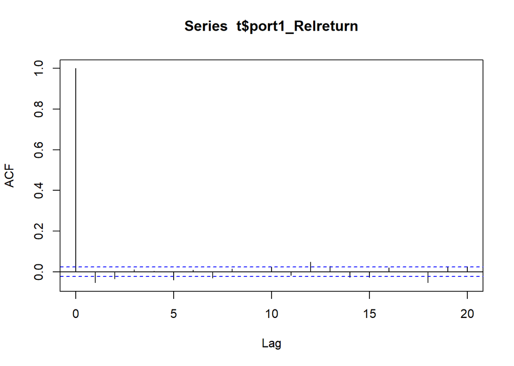

```r
acf(t$port1_Relreturn,lag.max = 20,type='correlation')
```

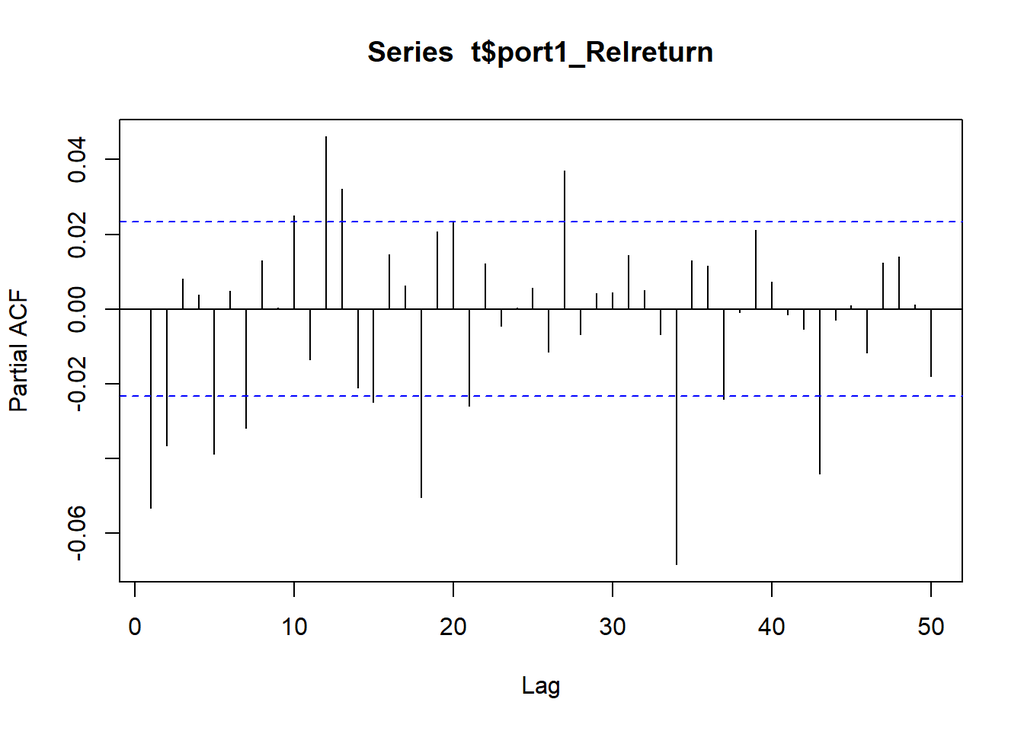

```r
pacf(t$port1_Relreturn,lag.max = 50)
```

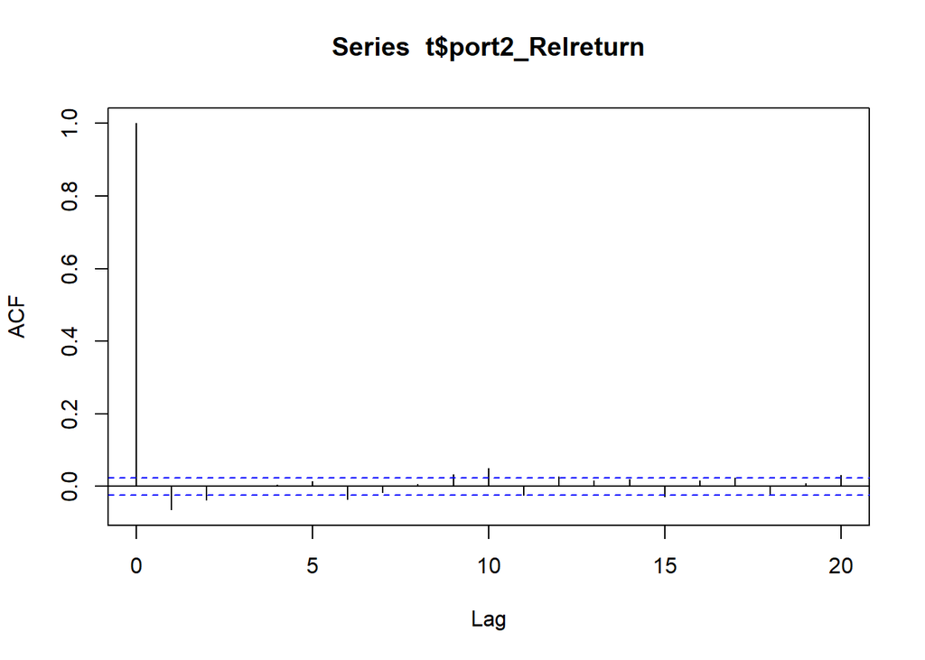

```r
acf(t$port2_Relreturn,lag.max = 20,type='correlation')
```

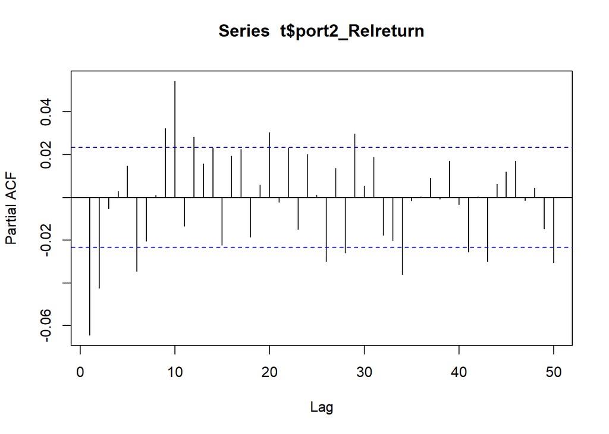

```r
pacf(t$port2_Relreturn,lag.max = 50)
```

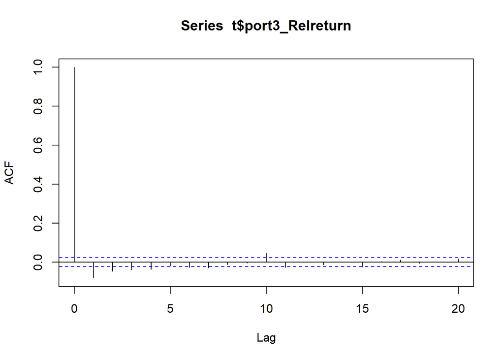

```r
acf(t$port3_Relreturn,lag.max = 20,type='correlation')
```

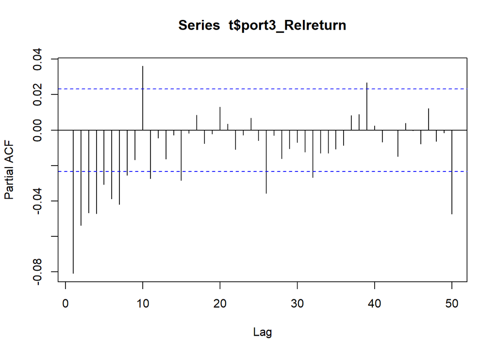

```r
pacf(t$port3_Relreturn,lag.max = 50)
```

# Scatter of RelReturn

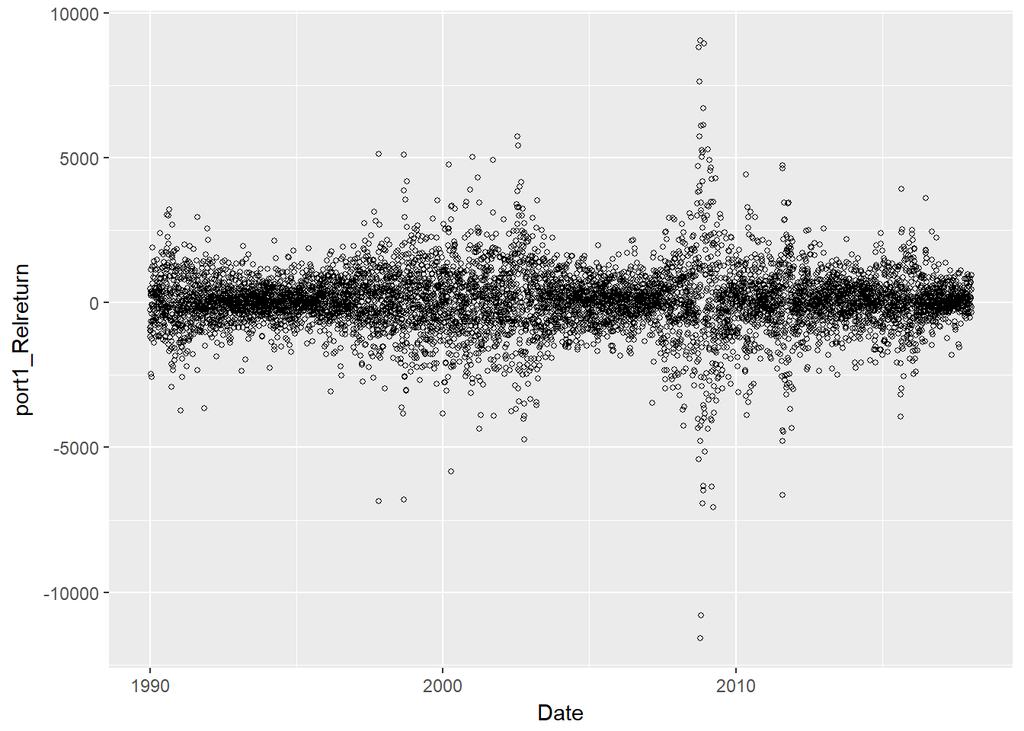

```r
ggplot(t,aes(x=Date)) +
  geom_point(aes(y=port1_Relreturn),size =1, shape= 1)
```

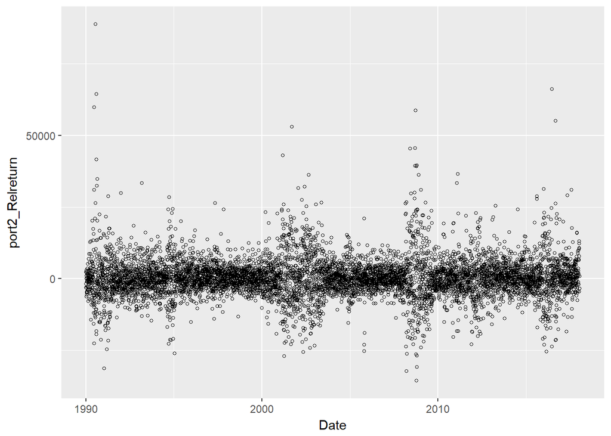

```r
ggplot(t,aes(x=Date)) +
  geom_point(aes(y=port2_Relreturn),size =1, shape= 1)
```

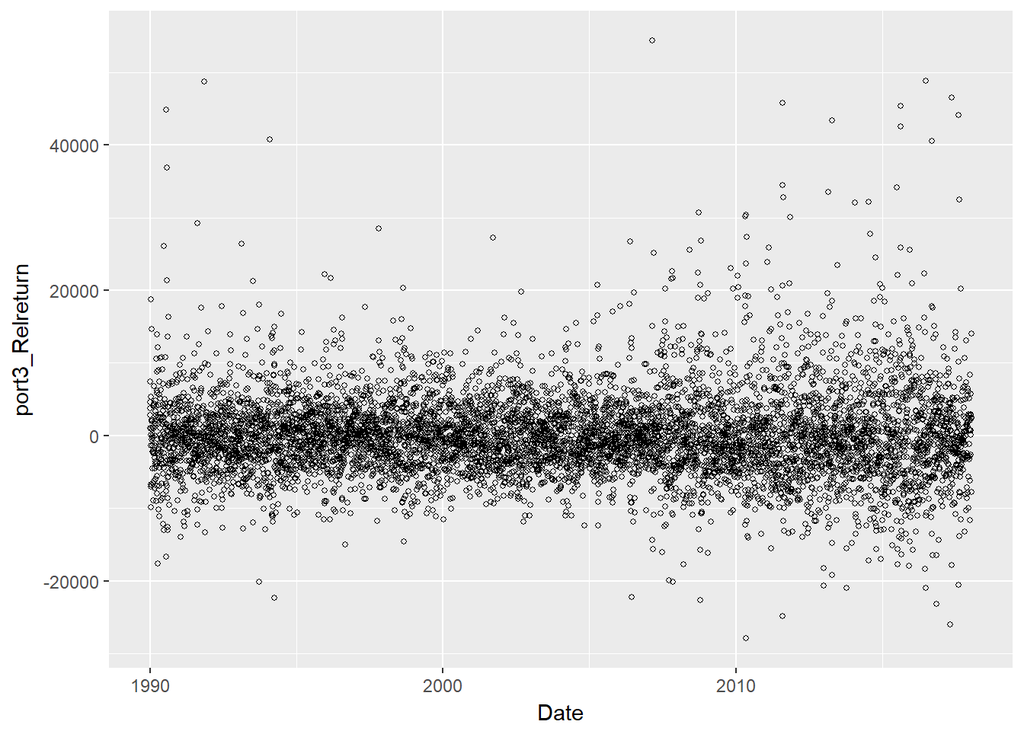

```r
ggplot(t,aes(x=Date)) +
  geom_point(aes(y=port3_Relreturn),size =1, shape= 1)
```